# HW2_B66043

Dzvezdana Arsovska

February 25, 2017

## *Exercise 1*

For the provided data set answer the following questions:

1. What is the data about?
2. What are different features and their types (discrete, continuous etc, range of values, possible meaning of the features)?
3. How many rows are in the dataset?

Perform data cleaning and explain the changes that you made.

**Solution:**

1. The *Adult data* set initially consists of $12$ features that enable us to make different comparisons and analysis. One of the things that the *Adult data* set represents are the salaries, the capital gain and the capital loss of adult man and women. This data set enables us to compare the income of adults depending on their education, native country, age and the employment. Also we can analyze possible connection between the job satisfaction and the employment type.
2. The *Adult data* set contains the following features: *X, age, workclass, education, occupation, capital.gain, captital.loss, native.country, salaries, jobsatisfaction, male and female*.
- *X*: Represents the row number and it is an integer with range between $1$ and $32561$.
- *Age*: Represents the age of the man and the women in the data set and it is an continous atribute. The range of this feature without cleaning is between $-57$ and $320$ which is obviously an incorect range. The correct range of this feature after the cleaning is between $17$ and $90$ years.
- *Workclass*: Represents the sector in which the adults are working (in case they are employed). Some of the listed occupations are: Private, Federal government, Local government etc.
- *Education*: Represents the level of education of the adults.
- *Capital.gain* and *Capital.loss*: Represent the increase/decrease in the value of a capital asset owned by the adults. They are continous integers. The range of the capital gain is between $0$ and $99999$ and the range of the capital loss is between $0$ and $4356$.
- *Native.country*: Represnets the country of residence of the adults. The most frequent country in this data set is the USA.
- *Salaries*: Reperesent the adult’s salary. This feature is a float ranging between $38.34125$ and $140000$.
- *Ocupation*: Represents the different types of adult’s jobs, for example: Sales, Transport etc.
- *Job Satisfaction*: Represent the job satisfaction of the adults. It is a continous integer between $0$ and $15$. $15$ represent the highest job satisfaction.
- *Male*: This feature has two values $1$ meaning the adult is a male and $NA$, meaning it’s not.
- *Female*: This feature has two values $1$ meaning the adult is a female and $NA$, meaning it’s not.

The above mentioned ranges and types were found using Open Refine. For demonstration, the range of the data (for example the age feature) and its type can be found in R using:

```r
adult_data <- read.csv("adult-csv.csv")

# Prints the range of the age column:
print(range(adult_data$age, na.rm = TRUE))
```

```
## [1] 17 90
```

```r
# Prints the type of the data:
sapply(adult_data, class)
```

```
##             age       workclass       education      occupation
##       "integer"        "factor"        "factor"        "factor"
##    capital.gain    capital.loss  native.country        salaries
##       "integer"       "integer"        "factor"       "numeric"
## jobsatisfaction          gender
##       "integer"        "factor"
```

3. The initial *Adult data* set has $32561$ rows.

*Data Cleaning*

It is obvious that some of the features are redundant. The X feature can be removed because R already provides us the information about the row number. Also the male and female features can be merged in one column that represents the adult’s gender.

Using Open Refine we can trim leading and trailing whitespaces that cause some features to be wrongly classified. Then we can examin the content of each individual column using the Text or the Numeric Facet. Using this I:

- corrected $-57$ to $57$ in the age feature;
- corrected *Privat* in *Private* in workclass thus merging them.
- corrected *Unitedstates* and *UnitedStates* in *United-States* thus merging them.

## *Exercise 2*

For each feature (depending on what’s applicable) show it’s:

- Mean, median, max, min, standard deviation (for numerical features)
- Frequency table (for categorical features)
- Are there missing values (how many)
- Plot showing the distribution or frequencies of values (choose a suitable plot for feature type)

Comment on the implications of the outcome (is the distribution skewed - more small/large values, any unexpectancies).

**Solution:**

The values for the min, max median, mean and the standard deviation for different features are calculated using R and their values are:

*Age* feature:

- min: $17$
- max: $90$
- median: $37$
- mean: $38.56071$
- standard deviation: $13.64282$

*Capital.gain* feature:

- min: $0$;
- max: $99999$;
- median: $0$;
- mean: $1077.649$;
- standard deviation: $7385.292$;

*Capital.loss* feature:

- min: $0$;
- max: $4356$;
- median: $0$;
- mean: $87.30383$;
- standard deviation: $402.9602

*Salaries* feature:

- min: $38.34125$
- max: $140000$
- median: $33927$
- mean: $39306.46$
- standard deviation: $17356.39$

*Jobsatisfaction* feature:

- min: $0$
- max: $15$
- median: $7$
- mean: $7.548771$
- standard deviation: $4.457437$

The frequency tables for the categorical features are:

```r
tab_workclass <- table(adult_data$workclass)
tab_workclass
```

```
##
##      Federal-gov        Local-gov     Never-worked          Private
##              960             2093                7            22696
##     Self-emp-inc Self-emp-not-inc        State-gov      Without-pay
##             1116             2541             1298               14
```

```r
tab_education <- table(adult_data$education)
tab_education
```

```
##
##         10th         11th         12th      1st-4th      5th-6th
##          933         1175          433          168          333
##      7th-8th          9th   Assoc-acdm    Assoc-voc    Bachelors
##          646          514         1067         1382         5355
##    Doctorate      HS-grad      Masters    Preschool  Prof-school
##          413        10501         1723           51          576
## Some-college
##         7291
```

```r
tab_occupation <- table(adult_data$occupation)
tab_occupation
```

```
##
##       Adm-clerical       Armed-Forces       Craft-repair
##               3770                  9               4099
##    Exec-managerial    Farming-fishing  Handlers-cleaners
##               4066                994               1370
##  Machine-op-inspct      Other-service    Priv-house-serv
##               2002               3295                149
##     Prof-specialty    Protective-serv              Sales
##               4140                649               3650
##       Tech-support   Transport-moving
##                928               1597
```

```r
tab_native.country <- table(adult_data$native.country)
tab_native.country
```

```
##
##                   Cambodia                     Canada
##                         19                        121
##                      China                   Columbia
##                         75                         59
##                       Cuba         Dominican-Republic
##                         95                         70
##                    Ecuador                El-Salvador
##                         28                        106
##                    England                     France
##                         90                         29
##                    Germany                     Greece
##                        137                         29
##                  Guatemala                      Haiti
##                         64                         44
##         Holand-Netherlands                   Honduras
##                          1                         13
##                       Hong                    Hungary
##                         20                         13
##                      India                       Iran
##                        100                         43
##                    Ireland                      Italy
##                         24                         73
##                    Jamaica                      Japan
##                         81                         62
##                       Laos                     Mexico
##                         18                        643
##                  Nicaragua Outlying-US(Guam-USVI-etc)
##                         34                         14
##                       Peru                Philippines
##                         31                        198
##                     Poland                   Portugal
##                         60                         37
##                Puerto-Rico                   Scotland
##                        114                         12
##                      South                     Taiwan
##                         80                         51
##                   Thailand            Trinadad&Tobago
##                         18                         19
##              United-States                    Vietnam
##                      29170                         67
##                 Yugoslavia
##                         16
```

```r
tab_gender <- table(adult_data$gender)
tab_gender
```

```
##
##     F     M
## 10771 21790
```

The number of missing values in the *Adult data* set is:

```r
na_val <- table(complete.cases(adult_data))
# The number of NA values is:
print(na_val)
```

```
##
## FALSE  TRUE
##  2488 30073
```

```r
NA_data = (2488/32561) * 100
# There are 8% NA data.
```

Using histogram the distribution for the salaries, the capital.gain, capital.loss, jobsatisfaction and age are plotted.

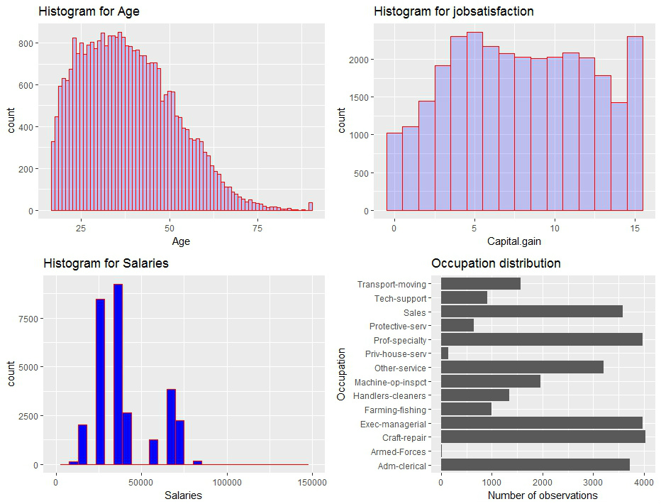

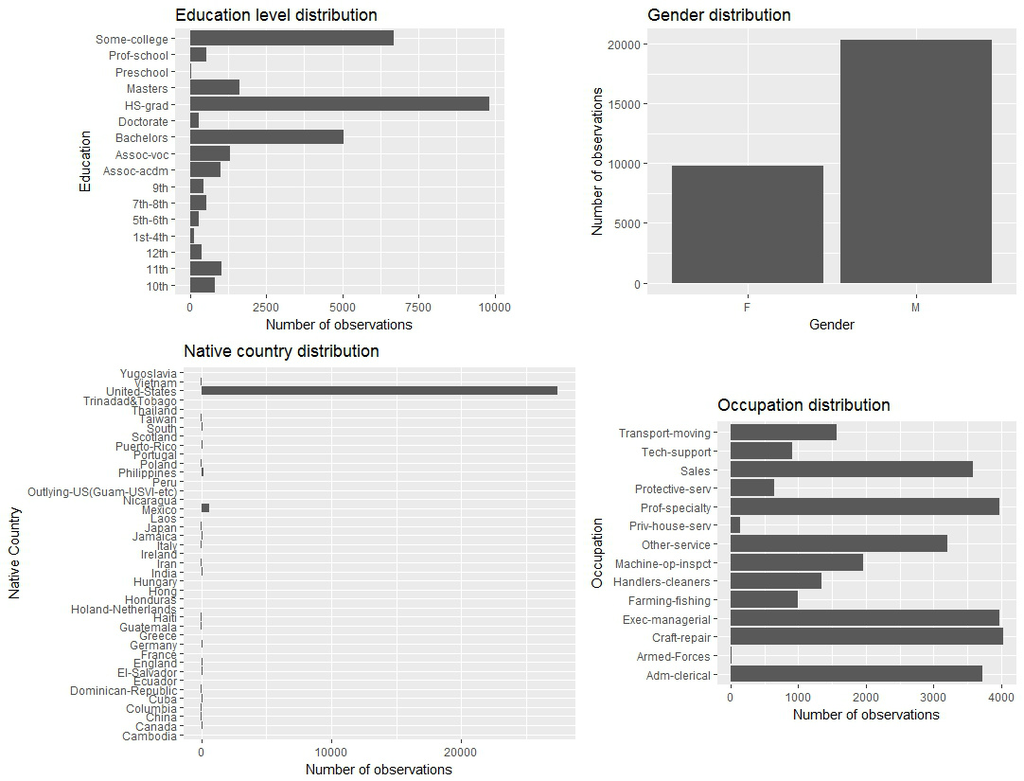

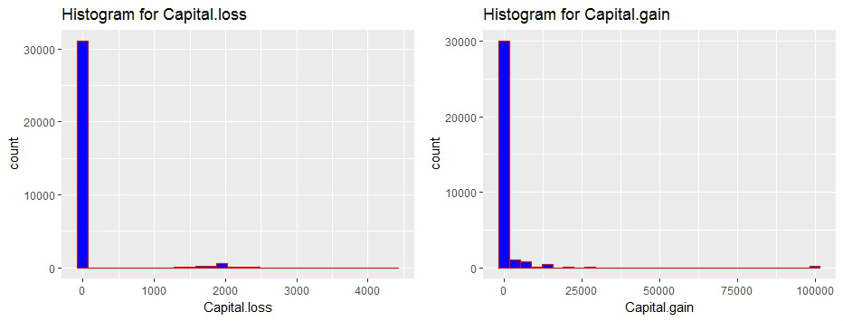

The skewness for the jobsatisfaction feature is not clearly defined. We can notice that most of the values are concentrated around the elements $5$ and $15$.

```r
data_v = na.omit(adult_data)
step = 10000  # interval length
n = ceiling(max(data_v$salaries)/step)  # number of intervals
data_v$salaries_interval = cut(data_v$salaries, step * (0:n))
data_v$salaries_median = ave(data_v$salaries, data_v$salaries_interval, FUN = median)
```

Also we can group them in $4$ groups depending on how big the salary is.

```r
data_v$salaries_group = ifelse(test = data_v[, "salaries"] >= 0 & data_v[, "salaries"] <=
    30000, yes = "Salary 0 - 30000", no = ifelse(test = data_v[, "salaries"] >
    30000 & data_v[, "salaries"] <= 60000, yes = "Salary 30001 - 60000", no = ifelse(test = data_v[,
    "salaries"] > 60000 & data_v[, "salaries"] <= 90000, yes = "Salary 60001 - 90000",
    no = "Salary 90001 - 140 000")))
```

We can notice that we have only $4$ salaries in the range between $90001$ and $140000$.

```r
table(data_v$salaries_group)
```

```
##
##       Salary 0 - 30000   Salary 30001 - 60000   Salary 60001 - 90000
##                  10633                  13164                   6272
## Salary 90001 - 140 000
##                      4
```

## *Exercise 3*

Identify potential outliers in the (numerical features) dataset by applying inter-quartile ranges (IQR) (range between the $25%$ and $75%$ quartiles) - are there values that are over $k*IQR$ larger the upper quartile or $k*IQR$ below lower quartile. Use $k=1.5$.

Explain if you should remove outliers. If so, then which ones. The outliers may show up from mistakes (incorrect data input, measurement error) or actually correct but rare values. You do not need to decide for each observation separately but explain your chosen outlier exclusion criteria in general terms. Decide and remove identified outliers and recalculate statistics from ex 2 for the changed features (including the plot). Any observations?

**Solution:**

Outlier is an observation point that is distant from other observations. Using R we can find the data points that are distinctly separate from the rest of the data.

```r
max_age <- quantile(adult_data[, 1], 0.75, na.rm = TRUE) + (IQR(adult_data[,
    1], na.rm = TRUE) * 1.5)
min_age <- quantile(adult_data[, 1], 0.25, na.rm = TRUE) - (IQR(adult_data[,
    1], na.rm = TRUE) * 1.5)
out_age <- which(adult_data[, 1] < min_age | adult_data[, 1] > max_age)

print(paste(length(out_age), sep = " "))
```

```
## [1] "143"
```

```r
print(paste(max_age, min_age))
```

```
## [1] "78 -2"
```

```r
out_age <- sort(out_age)

# adult_data <- adult_data[-out_age,] We can remove the outliers using this.
```

For the Age Feature we can see that we have $143$ outliers and all of them lie above the upper fence. However these outliers should not be removed because the reason for this values is not a measurment error (the age between $78$ and $90$ is a possible value).

We can visualize the outliers using box plot.

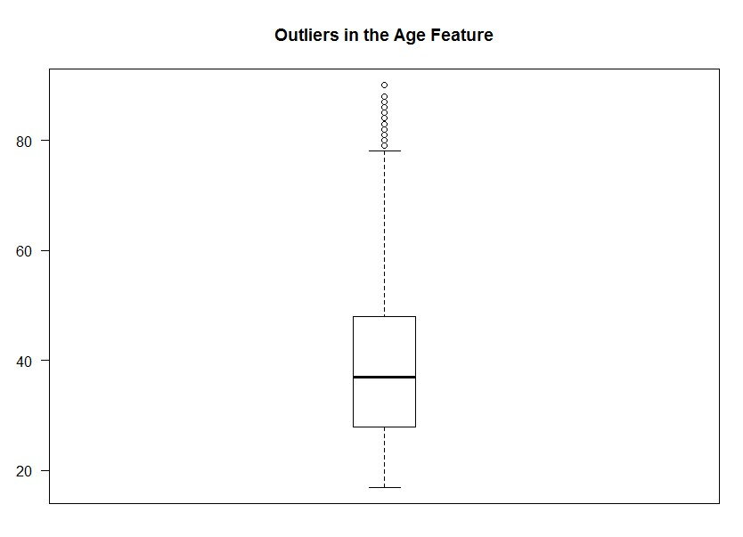

Similarly we calculate the outliers for capital.gain and capital.loss. For capital.gain we have $2712$ outliers and for capital.loss we have $1519$ outliers. In the both cases everything that is not zero is concidered to be an outlier. Removing this outliers depends of the final analysis we want to perform with out data set. The values above $0$ are possible values. If we remove the outliers we will get identical mean and median that will have a value of $0$.

For the salaries feature we have $195$ outliers and all of them lie above the upper fence (above $79983.5$). The values above $79983.5$ are possible because adults can have higher salary than this. As a result this outliers should not be removed. If we remove them we will get lower value for the mean which will be closer to the median.

The job satisfaction feature does not have any outliers.

The total number of outliers in the data set is $4569$.

## *Exercise 4*

There are some missing values in features age and native.country. Investigate, which cases of missing data do we have in each of our features (systematically or randomly missing). Make a decision if you can or should impute missing data in some of those features and explain your decision. If you decided to impute, do that (you don’t have to use anything too complicated) and compare relevant statistics and plots from ex 2 with the values on initial dataset. If you decide not to impute, explain (and convince us) on the reason why.

**Solution:**

Missing data, or missing values, occur when no data value is stored for the variable in an observation. This is a common occurrence that can have a significant effect on the conclusions that can be drawn from the data. The missing data in native.country occurs completely at random. In other words there is no clear pattern that connects the missing data in native.country with the other features and we can not find any convincing evidence that any connection exists.Although R eliminate cases with missing data, the $NA$ cases in this feature consist just $1.79%$ of the data set which means we have enough data to perform the analysis.

On the other hand in the age feature we can notice that all of the missing values occur when the education is Doctorate.This gives us an evidence that maybe the respondents refused to answer the question because of privacy or any other issues. A simple approach to deal with this missing data is to change the missing values with the median of the age of the adults whouse education is Doctorate. However, I do not expect significant changes in the distibution because the $NA$ cases in this feature consist just $0.29%$ of the data.

The median of the doctor’s age is $47$.

Changing the $NA$ values with $47$ in the age features result with the following values: mean: $38.5858$ median: $37$ standard deviation: $13.63024$

The median remains the same and the mean and the standard deviation have insignificant changes compared to the old values.

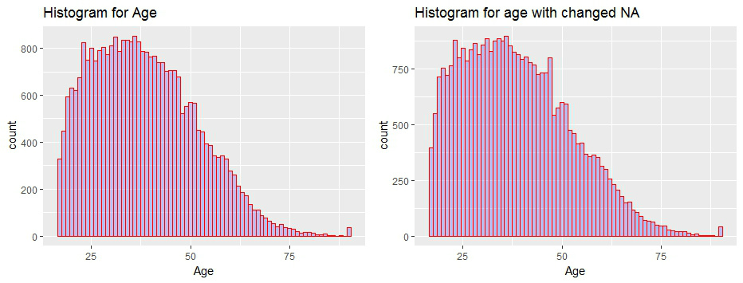

From the plots we can also notice that we did not introduce significant change in the distribtion.

## *Exercise 5*

Find 3 creative ways to describe the relationships between two or more variables (in R you can use ggplot2 package, in Python pandas, seaborn, matplotlib). Add these plots along with descriptions on what they show in your report. Don’t forget to add appropriate axis labels and titles.

**Solution:**

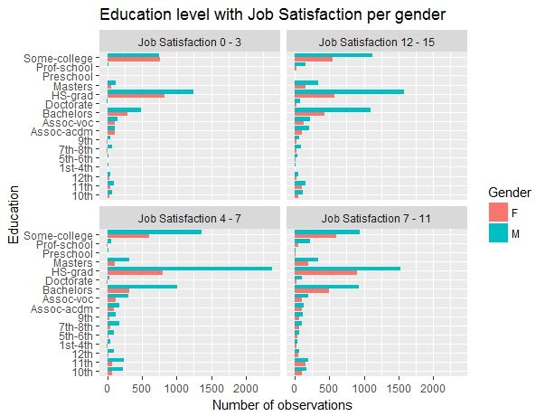

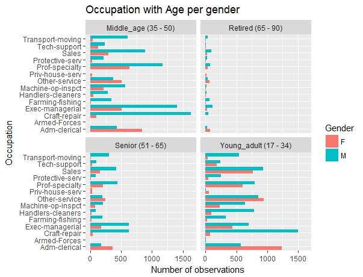

In the second plot I am comparing what is the most common employment type based of the age and the gender of the adults.

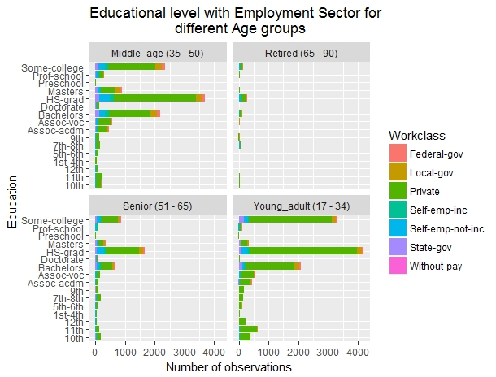

In the third plot I am comparing the workclass based on the educational level and the age of the adults. We can see that most of the adults work in the private sector.